# Electric bike power consumption

Lovdip Singh

## Question of interest/goal of the study

We are interested in investigating how the power consumption of an electric bike increases with the bikes speed.

## Read in and inspect the data:

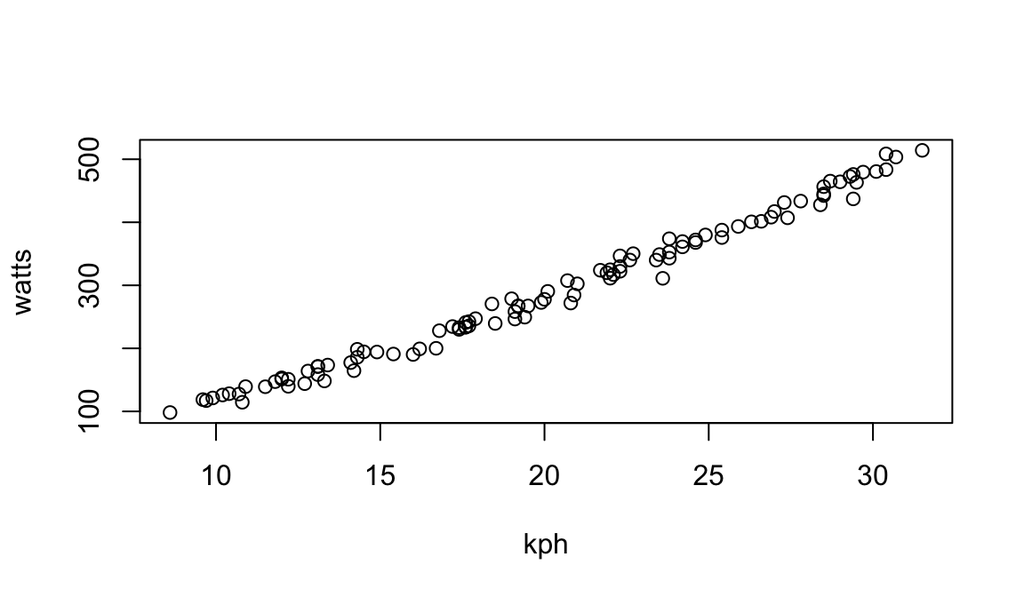

```r
Ebike.df=read.table("CyclePower.txt", header=T)
plot(watts~kph,data=Ebike.df)
```

The relationship between kph and watts appears to be a positive linear relationship. The variability appears to be constant and quite tight.

## Model fitting

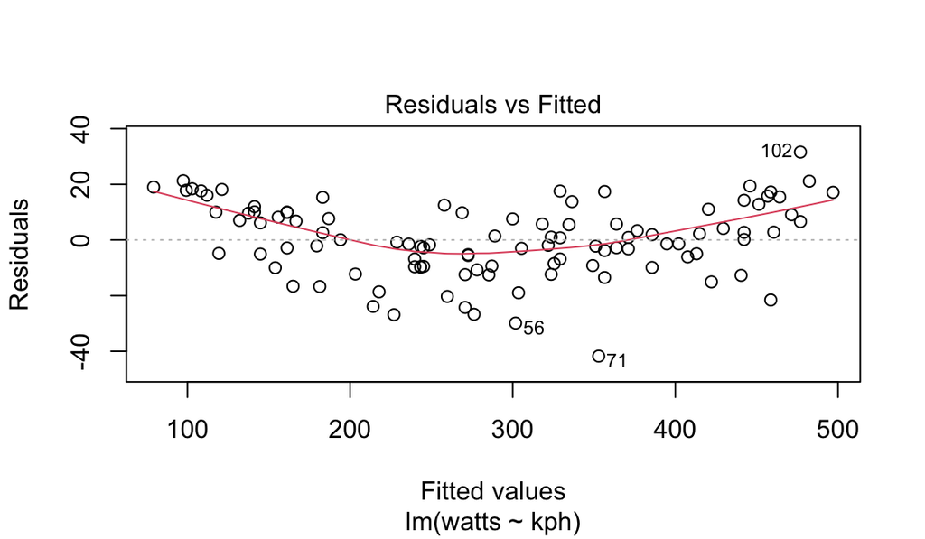

```r
Ebike.fit = lm(watts ~ kph, data = Ebike.df) #Linear model
plot(Ebike.fit, which = 1)
```

```r
summary(Ebike.fit)
```

```
##
## Call:
## lm(formula = watts ~ kph, data = Ebike.df)
##
## Residuals:
##     Min      1Q  Median      3Q     Max
## -41.744  -9.365   0.080   9.919  31.595
##
## Coefficients:
##             Estimate Std. Error t value Pr(>|t|)
## (Intercept) -77.7181     4.3908  -17.70   <2e-16 ***
## kph          18.2442     0.2079   87.74   <2e-16 ***
## ---
## Signif. codes:  0 '***' 0.001 '**' 0.01 '*' 0.05 '.' 0.1 ' ' 1
##
## Residual standard error: 13.26 on 103 degrees of freedom
## Multiple R-squared:  0.9868, Adjusted R-squared:  0.9867
## F-statistic:  7698 on 1 and 103 DF,  p-value: < 2.2e-16
```

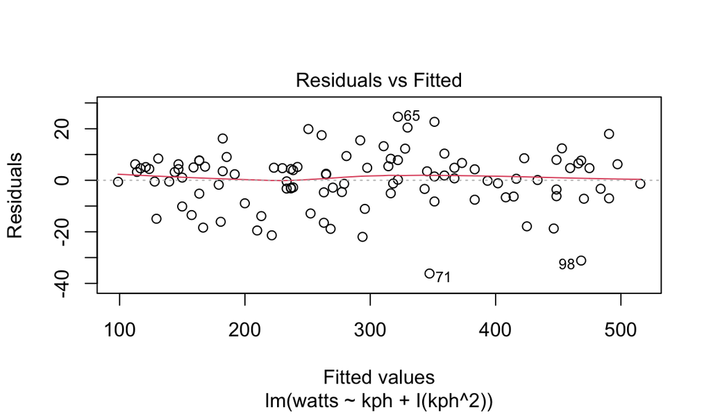

```r
Ebike.fit2 = lm(watts ~ kph + I(kph^2), data = Ebike.df) #Quadratic model
plot(Ebike.fit2, which = 1)
```

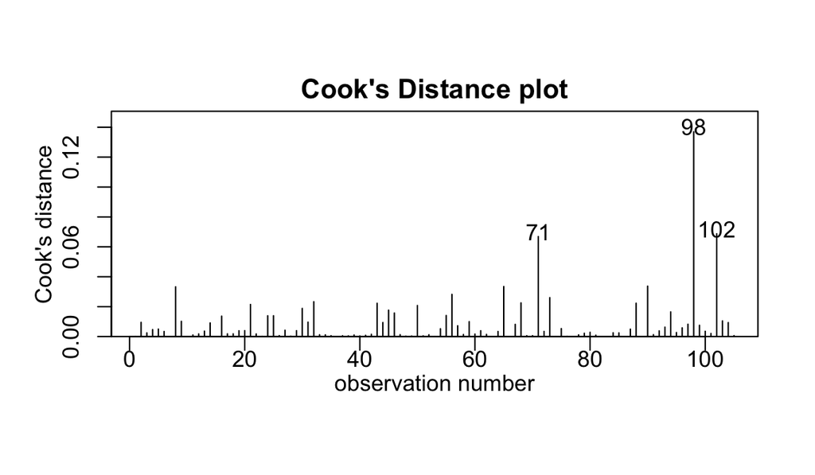

```r
cooks20x(Ebike.fit2)
```

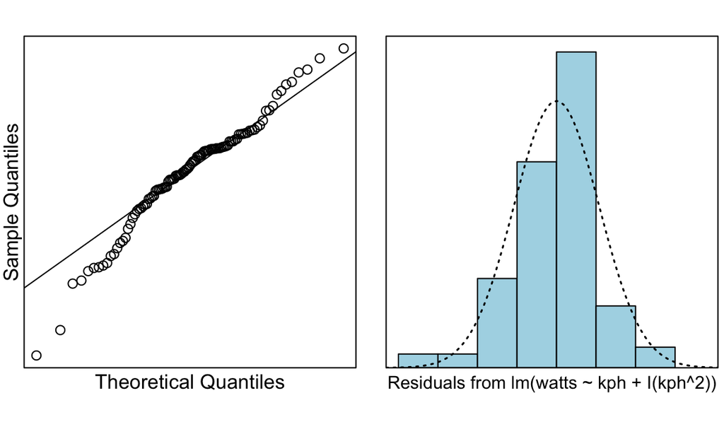

```r
normcheck(Ebike.fit2)
```

```r
summary(Ebike.fit2)
```

```
##
## Call:
## lm(formula = watts ~ kph + I(kph^2), data = Ebike.df)
##
## Residuals:
##     Min      1Q  Median      3Q     Max
## -36.182  -5.054   1.478   6.219  24.628
##
## Coefficients:
##             Estimate Std. Error t value Pr(>|t|)
## (Intercept) -1.80175   11.23558  -0.160    0.873
## kph          9.92299    1.17888   8.417 2.52e-13 ***
## I(kph^2)     0.20630    0.02892   7.134 1.45e-10 ***
## ---
## Signif. codes:  0 '***' 0.001 '**' 0.01 '*' 0.05 '.' 0.1 ' ' 1
##
## Residual standard error: 10.89 on 102 degrees of freedom
## Multiple R-squared:  0.9912, Adjusted R-squared:  0.991
## F-statistic:  5739 on 2 and 102 DF,  p-value: < 2.2e-16
```

```r
confint(Ebike.fit2)
```

```
##                  2.5 %     97.5 %
## (Intercept) -24.087469 20.4839735
## kph           7.584689 12.2612886
## I(kph^2)      0.148940  0.2636619
```

## Data with model superimposed

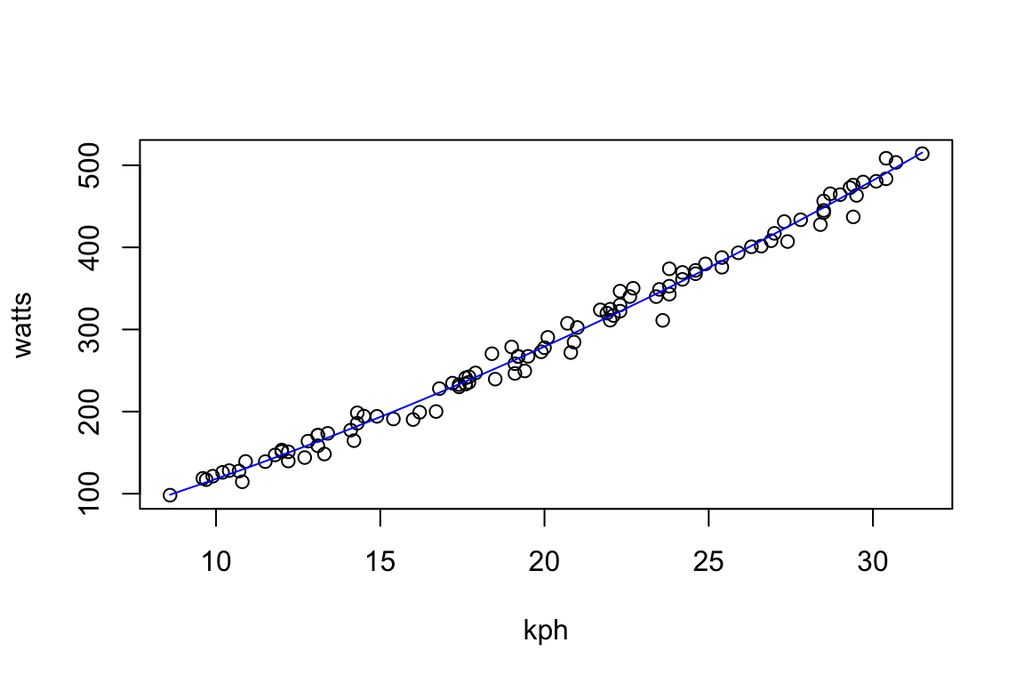

```r
plot(watts~kph,data=Ebike.df)
o = order(Ebike.df$kph)
lines(Ebike.df$kph[o], fitted(Ebike.fit2)[o], col = "blue")
```

## Prediction of power consumption at 20 kph

```r
predict(Ebike.fit2, data.frame(kph = 20), interval = "prediction")
```

```
##        fit      lwr      upr
## 1 279.1784 257.3702 300.9866
```

For an electric bike of the same model traveling at a speed of 20 kph, the power consumption of the electric bike is predicted to be between 257.37 and 300.99 watts.

This model is very useful for prediction as the model explains 99.12% of the variability in the data, the quadratic term is statistically significant with an extremely low p-value. The prediction interval was quite consistent with the observed values from the data set.

## Method and Assumption Checks

The scatter plot of power consumption (watts) vs speed (kph) suggested a positive linear relationship.

We began with a linear model to describe speed (kph) and power consumption (watts) for the electric bike observations. The residual plot for the fit of a simple linear model showed fairly constant scatter but had curvature, this model explained 98.68% of the variability in the data. A quadratic term was then added to the linear model.

The quadratic model improved the residual plot (average of residuals closer to 0) indicating the model was a better fit for the data. All model assumptions looked satisfied once we added the quadratic term to the linear model. There were no unduly influential points. The observations for each data point are assummed to be independent.

Our model is: $watts_i = β0 +β1 × kph_i +β2 × kph^2_i + ε_i$ where $\epsilon_i \sim iid ~ N(0,\sigma^2)$

Our final model explained 99.12% of the variability in the power consumption of the electric bike model.

## Executive Summary

We were interested in building a model to estimate power consumption (watts) with speed (kph) for a particular electric bike.

The relationship between expected power consumption (watts) and speed (kph) modelled was quadratic.

This model shows that for a unit increase in speed (kph), the increase in power consumption (watts) was greater as the speed (kph) increased.

The model should also be interpreted with caution for speeds close to zero. For example, for speeds of 0 kph, 15 kph and 30 kph, the estimated power consumption were between -24.09 to 20.48, 190.63 to 196.29 and 476.41 to 486.71 on average, respectively.